# case- SUCESS

## CASE NEON- Prever probabilidade de inadimplência

#### Probabilidade de inadimplência

Um dos assuntos que causam mais problemas para bancos, financiadoras, fintechs ou empresas sejam grandes ou pequenas, é a inadimplência dos clientes. Ao avaliar o comportamento do cliente se irá deixar de cumprir com as suas obrigações financeiras ajuda a saber o risco e implementar ações em clientes com maiores chances de serem não pagadores (risco de default) para que a companhia não sofra.

Utilizando os dados referente ao históricos de pagamentos e extratos de contas de clientes de cartão de crédito em Taiwan, no período de Abril de 2005 até Setembro de 2005, disponível no Kaggle "Default of Credit Card Clients Dataset"

#### Objetivo:

Prever a probabilidade de inadimplência dos clientes

#### Variável resposta:

1 se é inadimplente; 0 caso contrário

### Descrição das variáveis:

Variables ID: ID of each client

LIMIT_BAL: Amount of given credit in NT dollars (includes individual and family/supplementary credit)

SEX: Gender (1=male, 2=female)

EDUCATION: (1=graduate school, 2=university, 3=high school, 4=others, 5=unknown, 6=unknown)

MARRIAGE: Marital status (1=married, 2=single, 3=others)

AGE: Age in years

PAY_0: Repayment status in September, 2005 (-1=pay duly, 1=payment delay for one month, 2=payment delay for two months, ... 8=payment delay for eight months, 9=payment delay for nine months and above)

PAY_2: Repayment status in August, 2005 (scale same as above)

PAY_3: Repayment status in July, 2005 (scale same as above)

PAY_4: Repayment status in June, 2005 (scale same as above)

PAY_5: Repayment status in May, 2005 (scale same as above)

PAY_6: Repayment status in April, 2005 (scale same as above)

BILL_AMT1: Amount of bill statement in September, 2005 (NT dollar)

BILL_AMT2: Amount of bill statement in August, 2005 (NT dollar)

BILL_AMT3: Amount of bill statement in July, 2005 (NT dollar)

BILL_AMT4: Amount of bill statement in June, 2005 (NT dollar)

BILL_AMT5: Amount of bill statement in May, 2005 (NT dollar)

BILL_AMT6: Amount of bill statement in April, 2005 (NT dollar)

PAY_AMT1: Amount of previous payment in September, 2005 (NT dollar)

PAY_AMT2: Amount of previous payment in August, 2005 (NT dollar)

PAY_AMT3: Amount of previous payment in July, 2005 (NT dollar)

PAY_AMT4: Amount of previous payment in June, 2005 (NT dollar)

PAY_AMT5: Amount of previous payment in May, 2005 (NT dollar)

PAY_AMT6: Amount of previous payment in April, 2005 (NT dollar)

default.payment.next.month: Default payment (1=yes, 0=no)

```python
##### Importação das LIBS
import numpy as np
import pandas as pd

# visualização dos dados
import matplotlib.pyplot as plt
import seaborn as sns
pd.set_option('display.max_columns', None)

# estilo dos gráficos gerais
sns.set_style('dark')

# Biblioteca de Machine Learning (ML)
from sklearn.preprocessing import StandardScaler
from sklearn.preprocessing import LabelEncoder
from sklearn.impute import SimpleImputer
from sklearn.model_selection import train_test_split
from sklearn.metrics import classification_report, confusion_matrix
from sklearn.metrics import accuracy_score
from xgboost import XGBClassifier
from sklearn.linear_model import LogisticRegression
from sklearn.tree import DecisionTreeClassifier
from sklearn.ensemble import RandomForestClassifier
from sklearn.model_selection import cross_val_score, KFold, train_test_split

from sklearn.metrics import roc_auc_score ### métricas
from sklearn.model_selection import cross_validate

import shap

# filtrar mensagens de warning
import warnings
warnings.filterwarnings('ignore')
```

## Importação do dataset

Será utilizado a função read_csv() da biblioteca pandas. Em que, será visualizado a 5 primeiras entradas do nosso dataset para que possa verificar a estrutura dos dados inicialmente.

```python
### Importando o dataset:
dados_df= pd.read_csv('C:/Users/jessi/Downloads/UCI_Credit_Card.csv')

## Visualizando as 5 primeiras entradas:

dados_df.head()
```

|  | ID | LIMIT_BAL | SEX | EDUCATION | MARRIAGE | AGE | PAY_0 | PAY_2 | PAY_3 | PAY_4 | PAY_5 | PAY_6 | BILL_AMT1 | BILL_AMT2 | BILL_AMT3 | BILL_AMT4 | BILL_AMT5 | BILL_AMT6 | PAY_AMT1 | PAY_AMT2 | PAY_AMT3 | PAY_AMT4 | PAY_AMT5 | PAY_AMT6 | default.payment.next.month |
| --- | --- | --- | --- | --- | --- | --- | --- | --- | --- | --- | --- | --- | --- | --- | --- | --- | --- | --- | --- | --- | --- | --- | --- | --- | --- |
| 0 | 1 | 20000.0 | 2 | 2 | 1 | 24 | 2 | 2 | -1 | -1 | -2 | -2 | 3913.0 | 3102.0 | 689.0 | 0.0 | 0.0 | 0.0 | 0.0 | 689.0 | 0.0 | 0.0 | 0.0 | 0.0 | 1 |
| 1 | 2 | 120000.0 | 2 | 2 | 2 | 26 | -1 | 2 | 0 | 0 | 0 | 2 | 2682.0 | 1725.0 | 2682.0 | 3272.0 | 3455.0 | 3261.0 | 0.0 | 1000.0 | 1000.0 | 1000.0 | 0.0 | 2000.0 | 1 |
| 2 | 3 | 90000.0 | 2 | 2 | 2 | 34 | 0 | 0 | 0 | 0 | 0 | 0 | 29239.0 | 14027.0 | 13559.0 | 14331.0 | 14948.0 | 15549.0 | 1518.0 | 1500.0 | 1000.0 | 1000.0 | 1000.0 | 5000.0 | 0 |
| 3 | 4 | 50000.0 | 2 | 2 | 1 | 37 | 0 | 0 | 0 | 0 | 0 | 0 | 46990.0 | 48233.0 | 49291.0 | 28314.0 | 28959.0 | 29547.0 | 2000.0 | 2019.0 | 1200.0 | 1100.0 | 1069.0 | 1000.0 | 0 |
| 4 | 5 | 50000.0 | 1 | 2 | 1 | 57 | -1 | 0 | -1 | 0 | 0 | 0 | 8617.0 | 5670.0 | 35835.0 | 20940.0 | 19146.0 | 19131.0 | 2000.0 | 36681.0 | 10000.0 | 9000.0 | 689.0 | 679.0 | 0 |

### Análise exploratório dos dados:

```python
## Detectando se existem valores ausentes:
dados_df.info()

### Número total de valores ausentes:

print('Total de números ausentes:', dados_df.isnull().sum().sum())
```

```
<class 'pandas.core.frame.DataFrame'>
RangeIndex: 30000 entries, 0 to 29999
Data columns (total 25 columns):
 #   Column                      Non-Null Count  Dtype
---  ------                      --------------  -----
 0   ID                          30000 non-null  int64
 1   LIMIT_BAL                   30000 non-null  float64
 2   SEX                         30000 non-null  int64
 3   EDUCATION                   30000 non-null  int64
 4   MARRIAGE                    30000 non-null  int64
 5   AGE                         30000 non-null  int64
 6   PAY_0                       30000 non-null  int64
 7   PAY_2                       30000 non-null  int64
 8   PAY_3                       30000 non-null  int64
 9   PAY_4                       30000 non-null  int64
```

[output cut: 18 more lines]

```python
## Quantidade linhas x colunas
print(dados_df.shape)
```

```
(30000, 25)
```

```python
### Aprofundamento nos dados: Dos 30.000 observações,cada linha representa uma específica característica, que pode ter um unico número ID, e contém 24 diferentes informações sobre eles.
dados_df.nunique()
```

```
ID                            30000
LIMIT_BAL                        81
SEX                               2
EDUCATION                         7
MARRIAGE                          4
AGE                              56
PAY_0                            11
PAY_2                            11
PAY_3                            11
PAY_4                            11
PAY_5                            10
PAY_6                            10
BILL_AMT1                     22723
BILL_AMT2                     22346
BILL_AMT3                     22026
BILL_AMT4                     21548
BILL_AMT5                     21010
BILL_AMT6                     20604
PAY_AMT1                       7943
PAY_AMT2                       7899
PAY_AMT3                       7518
PAY_AMT4                       6937
PAY_AMT5                       6897
PAY_AMT6                       6939
default.payment.next.month        2
dtype: int64
```

```python
# check valores faltantes
dados_df.isna().sum()
```

```
ID                            0
LIMIT_BAL                     0
SEX                           0
EDUCATION                     0
MARRIAGE                      0
AGE                           0
PAY_0                         0
PAY_2                         0
PAY_3                         0
PAY_4                         0
PAY_5                         0
PAY_6                         0
BILL_AMT1                     0
BILL_AMT2                     0
BILL_AMT3                     0
BILL_AMT4                     0
BILL_AMT5                     0
BILL_AMT6                     0
PAY_AMT1                      0
PAY_AMT2                      0
PAY_AMT3                      0
PAY_AMT4                      0
PAY_AMT5                      0
PAY_AMT6                      0
default.payment.next.month    0
dtype: int64
```

### Estatísticas descritivas no conjunto de dados:

```python
dados_df.describe().T
```

|  | count | mean | std | min | 25% | 50% | 75% | max |
| --- | --- | --- | --- | --- | --- | --- | --- | --- |
| ID | 30000.0 | 15000.500000 | 8660.398374 | 1.0 | 7500.75 | 15000.5 | 22500.25 | 30000.0 |
| LIMIT_BAL | 30000.0 | 167484.322667 | 129747.661567 | 10000.0 | 50000.00 | 140000.0 | 240000.00 | 1000000.0 |
| SEX | 30000.0 | 1.603733 | 0.489129 | 1.0 | 1.00 | 2.0 | 2.00 | 2.0 |
| EDUCATION | 30000.0 | 1.853133 | 0.790349 | 0.0 | 1.00 | 2.0 | 2.00 | 6.0 |
| MARRIAGE | 30000.0 | 1.551867 | 0.521970 | 0.0 | 1.00 | 2.0 | 2.00 | 3.0 |
| AGE | 30000.0 | 35.485500 | 9.217904 | 21.0 | 28.00 | 34.0 | 41.00 | 79.0 |
| PAY_0 | 30000.0 | -0.016700 | 1.123802 | -2.0 | -1.00 | 0.0 | 0.00 | 8.0 |
| PAY_2 | 30000.0 | -0.133767 | 1.197186 | -2.0 | -1.00 | 0.0 | 0.00 | 8.0 |
| PAY_3 | 30000.0 | -0.166200 | 1.196868 | -2.0 | -1.00 | 0.0 | 0.00 | 8.0 |
| PAY_4 | 30000.0 | -0.220667 | 1.169139 | -2.0 | -1.00 | 0.0 | 0.00 | 8.0 |
| PAY_5 | 30000.0 | -0.266200 | 1.133187 | -2.0 | -1.00 | 0.0 | 0.00 | 8.0 |
| PAY_6 | 30000.0 | -0.291100 | 1.149988 | -2.0 | -1.00 | 0.0 | 0.00 | 8.0 |
| BILL_AMT1 | 30000.0 | 51223.330900 | 73635.860576 | -165580.0 | 3558.75 | 22381.5 | 67091.00 | 964511.0 |
| BILL_AMT2 | 30000.0 | 49179.075167 | 71173.768783 | -69777.0 | 2984.75 | 21200.0 | 64006.25 | 983931.0 |
| BILL_AMT3 | 30000.0 | 47013.154800 | 69349.387427 | -157264.0 | 2666.25 | 20088.5 | 60164.75 | 1664089.0 |
| BILL_AMT4 | 30000.0 | 43262.948967 | 64332.856134 | -170000.0 | 2326.75 | 19052.0 | 54506.00 | 891586.0 |
| BILL_AMT5 | 30000.0 | 40311.400967 | 60797.155770 | -81334.0 | 1763.00 | 18104.5 | 50190.50 | 927171.0 |
| BILL_AMT6 | 30000.0 | 38871.760400 | 59554.107537 | -339603.0 | 1256.00 | 17071.0 | 49198.25 | 961664.0 |
| PAY_AMT1 | 30000.0 | 5663.580500 | 16563.280354 | 0.0 | 1000.00 | 2100.0 | 5006.00 | 873552.0 |
| PAY_AMT2 | 30000.0 | 5921.163500 | 23040.870402 | 0.0 | 833.00 | 2009.0 | 5000.00 | 1684259.0 |
| PAY_AMT3 | 30000.0 | 5225.681500 | 17606.961470 | 0.0 | 390.00 | 1800.0 | 4505.00 | 896040.0 |
| PAY_AMT4 | 30000.0 | 4826.076867 | 15666.159744 | 0.0 | 296.00 | 1500.0 | 4013.25 | 621000.0 |
| PAY_AMT5 | 30000.0 | 4799.387633 | 15278.305679 | 0.0 | 252.50 | 1500.0 | 4031.50 | 426529.0 |
| PAY_AMT6 | 30000.0 | 5215.502567 | 17777.465775 | 0.0 | 117.75 | 1500.0 | 4000.00 | 528666.0 |
| default.payment.next.month | 30000.0 | 0.221200 | 0.415062 | 0.0 | 0.00 | 0.0 | 0.00 | 1.0 |

Alguns pontos importantes:

- A coluna ID: identifica o usuário, pode ser descartada pois não agrega na análise;
- Default payment (1=yes, 0=no): é nossa variável alvo;
- As colunas SEX, EDUCATION, MARRIAGE, PAY_0, PAY_2, PAY_3, PAY_4, PAY_5, PAY_6, default_payment_next_month são variáveis categóricas;

Além disso, ao olhar a tabela com as informações descritivas aparentemente não existem valores (infinitos) que possam interferir no modelo.

```python
### Tamanho do dataset:
print("TAMANHO DO DATASET")
print(f"OBSERVATIONS:\t {dados_df.shape[0]} ")
print(f"FEATURES:\t {dados_df.shape[1]} ")
```

```
TAMANHO DO DATASET
OBSERVATIONS:	 30000
FEATURES:	 25
```

```python
### renomeando essa coluna para facilitar as manipulações:
dados_df.rename(columns={'default.payment.next.month':'def_pay'}, inplace=True)
```

### Descritiva por variáveis:

```python
#Descrição de variáveis categóricas:
dados_df[['SEX', 'EDUCATION', 'MARRIAGE']].describe()

# ### SEX: Gender (1=male, 2=female)
# #EDUCATION: (1=graduate school, 2=university, 3=high school, 4=others, 5=unknown, 6=unknown)
# MARRIAGE: Marital status (1=married, 2=single, 3=others)


## Estranho que para a target "Education" categoria 5 e 6 estão desconhecidas e a categoria 0 é desconhecida na documentação
## Similar a coluna "Marriage" que não está na documentação o label 0;
```

|  | SEX | EDUCATION | MARRIAGE |
| --- | --- | --- | --- |
| count | 30000.000000 | 30000.000000 | 30000.000000 |
| mean | 1.603733 | 1.853133 | 1.551867 |
| std | 0.489129 | 0.790349 | 0.521970 |
| min | 1.000000 | 0.000000 | 0.000000 |
| 25% | 1.000000 | 1.000000 | 1.000000 |
| 50% | 2.000000 | 2.000000 | 2.000000 |
| 75% | 2.000000 | 2.000000 | 2.000000 |
| max | 2.000000 | 6.000000 | 3.000000 |

```python
# Descrição do atraso no pagamento:
dados_df[['PAY_0', 'PAY_2', 'PAY_3', 'PAY_4', 'PAY_5', 'PAY_6']].describe()



### Todas as colunas apresentam um lab -2 e não está na documentação do dataset
```

|  | PAY_0 | PAY_2 | PAY_3 | PAY_4 | PAY_5 | PAY_6 |
| --- | --- | --- | --- | --- | --- | --- |
| count | 30000.000000 | 30000.000000 | 30000.000000 | 30000.000000 | 30000.000000 | 30000.000000 |
| mean | -0.016700 | -0.133767 | -0.166200 | -0.220667 | -0.266200 | -0.291100 |
| std | 1.123802 | 1.197186 | 1.196868 | 1.169139 | 1.133187 | 1.149988 |
| min | -2.000000 | -2.000000 | -2.000000 | -2.000000 | -2.000000 | -2.000000 |
| 25% | -1.000000 | -1.000000 | -1.000000 | -1.000000 | -1.000000 | -1.000000 |
| 50% | 0.000000 | 0.000000 | 0.000000 | 0.000000 | 0.000000 | 0.000000 |
| 75% | 0.000000 | 0.000000 | 0.000000 | 0.000000 | 0.000000 | 0.000000 |
| max | 8.000000 | 8.000000 | 8.000000 | 8.000000 | 8.000000 | 8.000000 |

```python
# Descrição do extrato na fatura
dados_df[['BILL_AMT1', 'BILL_AMT2', 'BILL_AMT3', 'BILL_AMT4', 'BILL_AMT5', 'BILL_AMT6']].describe()


### Estranho esses valores negativos. Como pode-se considerar como crédito?
```

|  | BILL_AMT1 | BILL_AMT2 | BILL_AMT3 | BILL_AMT4 | BILL_AMT5 | BILL_AMT6 |
| --- | --- | --- | --- | --- | --- | --- |
| count | 30000.000000 | 30000.000000 | 3.000000e+04 | 30000.000000 | 30000.000000 | 30000.000000 |
| mean | 51223.330900 | 49179.075167 | 4.701315e+04 | 43262.948967 | 40311.400967 | 38871.760400 |
| std | 73635.860576 | 71173.768783 | 6.934939e+04 | 64332.856134 | 60797.155770 | 59554.107537 |
| min | -165580.000000 | -69777.000000 | -1.572640e+05 | -170000.000000 | -81334.000000 | -339603.000000 |
| 25% | 3558.750000 | 2984.750000 | 2.666250e+03 | 2326.750000 | 1763.000000 | 1256.000000 |
| 50% | 22381.500000 | 21200.000000 | 2.008850e+04 | 19052.000000 | 18104.500000 | 17071.000000 |
| 75% | 67091.000000 | 64006.250000 | 6.016475e+04 | 54506.000000 | 50190.500000 | 49198.250000 |
| max | 964511.000000 | 983931.000000 | 1.664089e+06 | 891586.000000 | 927171.000000 | 961664.000000 |

```python
# Descrição do pagamento anterior:
dados_df[['PAY_AMT1', 'PAY_AMT2', 'PAY_AMT3', 'PAY_AMT4', 'PAY_AMT5', 'PAY_AMT6']].describe()
```

|  | PAY_AMT1 | PAY_AMT2 | PAY_AMT3 | PAY_AMT4 | PAY_AMT5 | PAY_AMT6 |
| --- | --- | --- | --- | --- | --- | --- |
| count | 30000.000000 | 3.000000e+04 | 30000.00000 | 30000.000000 | 30000.000000 | 30000.000000 |
| mean | 5663.580500 | 5.921163e+03 | 5225.68150 | 4826.076867 | 4799.387633 | 5215.502567 |
| std | 16563.280354 | 2.304087e+04 | 17606.96147 | 15666.159744 | 15278.305679 | 17777.465775 |
| min | 0.000000 | 0.000000e+00 | 0.00000 | 0.000000 | 0.000000 | 0.000000 |
| 25% | 1000.000000 | 8.330000e+02 | 390.00000 | 296.000000 | 252.500000 | 117.750000 |
| 50% | 2100.000000 | 2.009000e+03 | 1800.00000 | 1500.000000 | 1500.000000 | 1500.000000 |
| 75% | 5006.000000 | 5.000000e+03 | 4505.00000 | 4013.250000 | 4031.500000 | 4000.000000 |
| max | 873552.000000 | 1.684259e+06 | 896040.00000 | 621000.000000 | 426529.000000 | 528666.000000 |

### Tratando os casos encontrados acima:

```python
### Renomeando a coluna PAY_0 para PAY_1
dados_df.rename(columns={'PAY_0':'PAY_1'}, inplace=True)
dados_df.head()
```

|  | ID | LIMIT_BAL | SEX | EDUCATION | MARRIAGE | AGE | PAY_1 | PAY_2 | PAY_3 | PAY_4 | PAY_5 | PAY_6 | BILL_AMT1 | BILL_AMT2 | BILL_AMT3 | BILL_AMT4 | BILL_AMT5 | BILL_AMT6 | PAY_AMT1 | PAY_AMT2 | PAY_AMT3 | PAY_AMT4 | PAY_AMT5 | PAY_AMT6 | def_pay |
| --- | --- | --- | --- | --- | --- | --- | --- | --- | --- | --- | --- | --- | --- | --- | --- | --- | --- | --- | --- | --- | --- | --- | --- | --- | --- |
| 0 | 1 | 20000.0 | 2 | 2 | 1 | 24 | 2 | 2 | -1 | -1 | -2 | -2 | 3913.0 | 3102.0 | 689.0 | 0.0 | 0.0 | 0.0 | 0.0 | 689.0 | 0.0 | 0.0 | 0.0 | 0.0 | 1 |
| 1 | 2 | 120000.0 | 2 | 2 | 2 | 26 | -1 | 2 | 0 | 0 | 0 | 2 | 2682.0 | 1725.0 | 2682.0 | 3272.0 | 3455.0 | 3261.0 | 0.0 | 1000.0 | 1000.0 | 1000.0 | 0.0 | 2000.0 | 1 |
| 2 | 3 | 90000.0 | 2 | 2 | 2 | 34 | 0 | 0 | 0 | 0 | 0 | 0 | 29239.0 | 14027.0 | 13559.0 | 14331.0 | 14948.0 | 15549.0 | 1518.0 | 1500.0 | 1000.0 | 1000.0 | 1000.0 | 5000.0 | 0 |
| 3 | 4 | 50000.0 | 2 | 2 | 1 | 37 | 0 | 0 | 0 | 0 | 0 | 0 | 46990.0 | 48233.0 | 49291.0 | 28314.0 | 28959.0 | 29547.0 | 2000.0 | 2019.0 | 1200.0 | 1100.0 | 1069.0 | 1000.0 | 0 |
| 4 | 5 | 50000.0 | 1 | 2 | 1 | 57 | -1 | 0 | -1 | 0 | 0 | 0 | 8617.0 | 5670.0 | 35835.0 | 20940.0 | 19146.0 | 19131.0 | 2000.0 | 36681.0 | 10000.0 | 9000.0 | 689.0 | 679.0 | 0 |

Como existem algumas categorias que estão mal rotuladas ou o mesmo sem documentação, segue-se a nova arcação:

- Considera-se 0 da coluna 'Marriage' como outro, sendo 3
- Considera-se 0 não documentado e 5,6 (desconhecido na documentação) da coluna 'EDUCATION' como outro, sendo 4

```python
# Alterando as categorias 0,5,6 para 4 da target 'EDUCATION'
dados_df['EDUCATION'] = dados_df['EDUCATION'].apply(lambda x: 4 if x in [0, 5, 6] else x)
```

```python
# Alterando a categoria 0 para 3 da target 'MARRAIGE'
dados_df['MARRIAGE'] = dados_df['MARRIAGE'].replace(0, 3)
```

Outro tratamento a ser realizado é com relação a variável PAY_N(1,2,3,4,5,6) que se refere ao atraso no pagamento, em que, na marcação existem -1 (ou seja, está dentro do prazo) e -2, 0 sem descrição do que possa ser, porém avaliando pode-se considerar como 0 que é um pagamento dentro do prazo em ambos os casos.

```python
### Redefinindo marcações:

def replace_to_zero(col):
    troca = (dados_df[col] == -2) | (dados_df[col] == -1) | (dados_df[col] == 0)
    dados_df.loc[troca, col] = 0

for i in ['PAY_1','PAY_2', 'PAY_3', 'PAY_4', 'PAY_5', 'PAY_6']:
    replace_to_zero(i)
```

```python
dados_df[['PAY_1', 'PAY_2', 'PAY_3', 'PAY_4', 'PAY_5', 'PAY_6']].describe()
```

|  | PAY_1 | PAY_2 | PAY_3 | PAY_4 | PAY_5 | PAY_6 |
| --- | --- | --- | --- | --- | --- | --- |
| count | 30000.000000 | 30000.000000 | 30000.000000 | 30000.000000 | 30000.00000 | 30000.000000 |
| mean | 0.356767 | 0.320033 | 0.304067 | 0.258767 | 0.22150 | 0.226567 |
| std | 0.760594 | 0.801727 | 0.790589 | 0.761113 | 0.71772 | 0.715438 |
| min | 0.000000 | 0.000000 | 0.000000 | 0.000000 | 0.00000 | 0.000000 |
| 25% | 0.000000 | 0.000000 | 0.000000 | 0.000000 | 0.00000 | 0.000000 |
| 50% | 0.000000 | 0.000000 | 0.000000 | 0.000000 | 0.00000 | 0.000000 |
| 75% | 0.000000 | 0.000000 | 0.000000 | 0.000000 | 0.00000 | 0.000000 |
| max | 8.000000 | 8.000000 | 8.000000 | 8.000000 | 8.00000 | 8.000000 |

### Categorias finais no dataset após o tratamento:

- COLUNA SEX: 1 MASCULINO, 2 FEMININO;
- EDUCATION: 1 graduate school, 2 university, 3 high school, 4 others;
- MARRIAGE: 1 married, 2 single, 3 others;
- PAY_1,2,3,4,5,6: 0 paid duly, 1 payment delay for one month, ..., 9 payment delay for nine months and above

### Visualização da variável de interesse (target: default_payment)

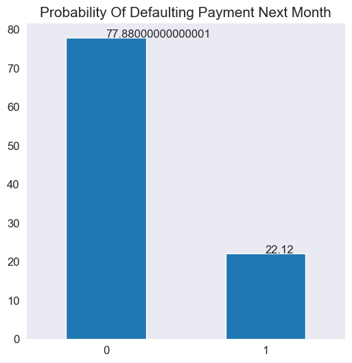

```python
def_cnt = (dados_df.def_pay.value_counts(normalize=True)*100)
def_cnt.plot.bar(figsize=(6,6))
plt.xticks(fontsize=12, rotation=0)
plt.yticks(fontsize=12)
plt.title("Probability Of Defaulting Payment Next Month", fontsize=15)
for x,y in zip([0,1],def_cnt):
    plt.text(x,y,y,fontsize=12)
plt.show()
```

```python
dados_df['def_pay'].value_counts()
```

```
0    23364
1     6636
Name: def_pay, dtype: int64
```

Ou seja, existem cerca de 22% dos clientes em defaul nos dados.

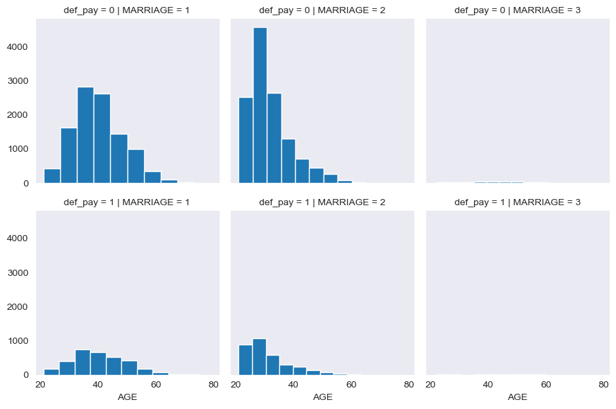

```python
g = sns.FacetGrid(dados_df, row='def_pay', col='MARRIAGE')
g = g.map(plt.hist, 'AGE')

plt.show()
```

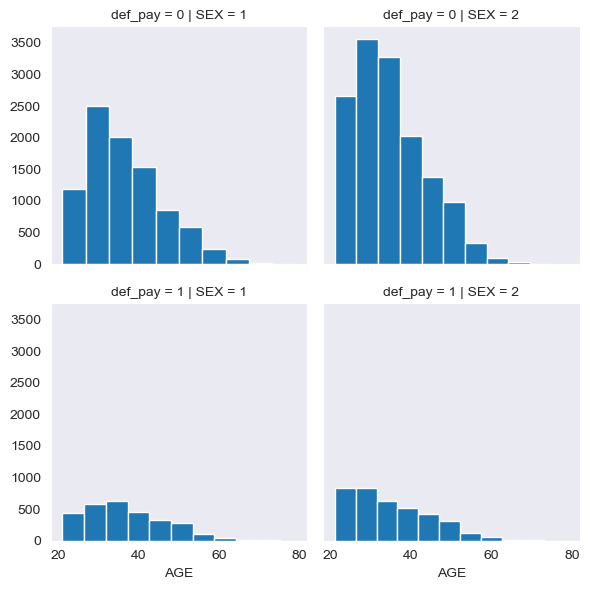

```python
g = sns.FacetGrid(dados_df, row='def_pay', col='SEX')
g = g.map(plt.hist, 'AGE')
```

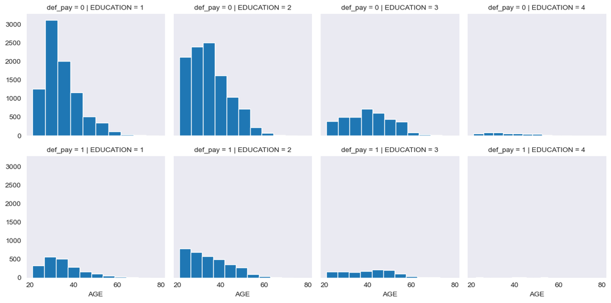

```python
g = sns.FacetGrid(dados_df, row='def_pay', col='EDUCATION')
g = g.map(plt.hist, 'AGE')
```

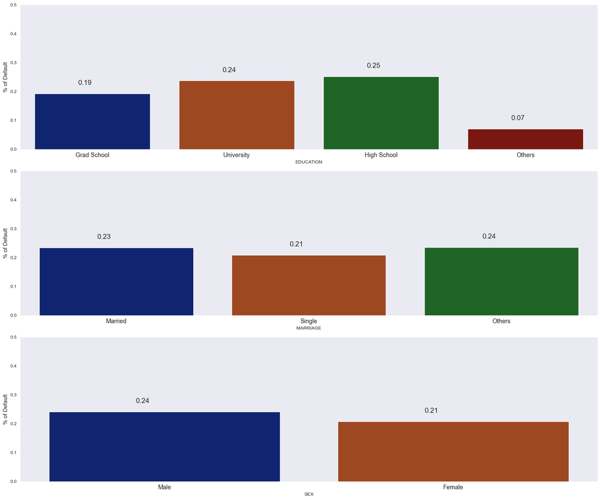

```python
fig, axes = plt.subplots(nrows=3, ncols=1, figsize=(18, 15))

# Bar plot for EDUCATION
ax1 = sns.barplot(x="EDUCATION", y="def_pay", data=dados_df, palette='dark', errorbar=None, ax=axes[0])
ax1.set_ylabel("% of Default", fontsize=12)
ax1.set_ylim(0, 0.5)
ax1.set_xticks([0, 1, 2, 3])
ax1.set_xticklabels(['Grad School', 'University', 'High School', 'Others'], fontsize=13)
for p in ax1.patches:
    ax1.annotate("%.2f" % (p.get_height()), (p.get_x() + 0.30, p.get_height() + 0.03), fontsize=15)

# Bar plot for MARRIAGE
ax2 = sns.barplot(x="MARRIAGE", y="def_pay", data=dados_df, palette='dark', errorbar=None, ax=axes[1])
ax2.set_ylabel("% of Default", fontsize=12)
ax2.set_ylim(0, 0.5)
ax2.set_xticks([0,1,2])
ax2.set_xticklabels(['Married', 'Single', 'Others'], fontsize=13)
for p in ax2.patches:
    ax2.annotate("%.2f" % (p.get_height()), (p.get_x() + 0.30, p.get_height() + 0.03), fontsize=15)

# Bar plot for SEX
ax3 = sns.barplot(x="SEX", y="def_pay", data=dados_df, palette='dark', errorbar=None, ax=axes[2])
ax3.set_ylabel("% of Default", fontsize=12)
ax3.set_ylim(0, 0.5)
ax3.set_xticks([0, 1])
ax3.set_xticklabels(['Male', 'Female'], fontsize=13)
for p in ax3.patches:
    ax3.annotate("%.2f" % (p.get_height()), (p.get_x() + 0.30, p.get_height() + 0.03), fontsize=15)

plt.tight_layout()
plt.show()
```

```
SEX
--------------------------
   Value  Count  Percentage
1      1  11888   39.626667
2      2  18112   60.373333
--------------------------
```

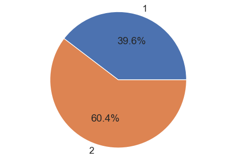

```
MARRIAGE
--------------------------
   Value  Count  Percentage
1      1  13659   45.530000
2      2  15964   53.213333
3      3    377    1.256667
--------------------------
```

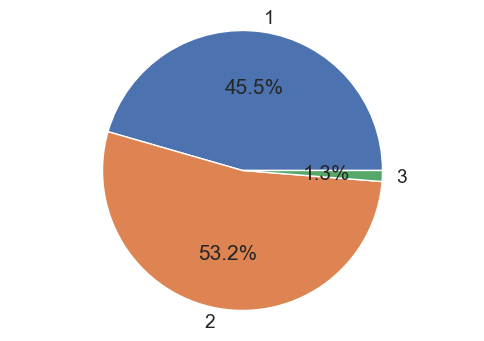

```
EDUCATION
--------------------------
   Value  Count  Percentage
1      1  10585   35.283333
2      2  14030   46.766667
3      3   4917   16.390000
4      4    468    1.560000
--------------------------
```

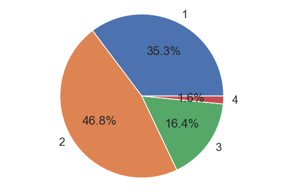

```python
def show_value_counts(col):
    print(col)
    value_counts = dados_df[col].value_counts()
    percentage = value_counts / len(dados_df) * 100
    result_df = pd.DataFrame({'Value': value_counts.index, 'Count': value_counts, 'Percentage': percentage})
    result_df = result_df.sort_values(by='Value')
    print('--------------------------')
    print(result_df)
    print('--------------------------')
    generate_pie_plot(result_df)


def generate_pie_plot(data_frame):
    plt.figure(figsize=(6, 4))
    plt.pie(data_frame['Count'], labels=data_frame['Value'], autopct='%1.1f%%')
    plt.axis('equal')
    plt.show()


show_value_counts('SEX')
show_value_counts('MARRIAGE')
show_value_counts('EDUCATION')
```

### TABELA CRUZADA:

```python
# Criar crosstab de contagem
tabela_contagem = pd.crosstab(dados_df['SEX'], dados_df['def_pay'])

# Criar crosstab de porcentagem
tabela_porcentagem = pd.crosstab(dados_df['SEX'], dados_df['def_pay'], normalize='index')

# Concatenar as duas tabelas
tabela_final = pd.concat([tabela_contagem, tabela_porcentagem], keys=['Contagem', 'Porcentagem'])
print(tabela_final)
```

```
def_pay                     0            1
            SEX
Contagem    1     9015.000000  2873.000000
            2    14349.000000  3763.000000
Porcentagem 1        0.758328     0.241672
            2        0.792237     0.207763
```

```python
# Criar crosstab de contagem
tabela_contagem = pd.crosstab(dados_df['MARRIAGE'], dados_df['def_pay'])

# Criar crosstab de porcentagem
tabela_porcentagem = pd.crosstab(dados_df['MARRIAGE'], dados_df['def_pay'], normalize='index')

# Concatenar as duas tabelas
tabela_final = pd.concat([tabela_contagem, tabela_porcentagem], keys=['Contagem', 'Porcentagem'])
print(tabela_final)
```

```
def_pay                          0            1
            MARRIAGE
Contagem    1         10453.000000  3206.000000
            2         12623.000000  3341.000000
            3           288.000000    89.000000
Porcentagem 1             0.765283     0.234717
            2             0.790717     0.209283
            3             0.763926     0.236074
```

```python
# Criar crosstab de contagem
tabela_contagem = pd.crosstab(dados_df['EDUCATION'], dados_df['def_pay'])

# Criar crosstab de porcentagem
tabela_porcentagem = pd.crosstab(dados_df['EDUCATION'], dados_df['def_pay'], normalize='index')

# Concatenar as duas tabelas
tabela_final = pd.concat([tabela_contagem, tabela_porcentagem], keys=['Contagem', 'Porcentagem'])
print(tabela_final)
```

```
def_pay                           0            1
            EDUCATION
Contagem    1           8549.000000  2036.000000
            2          10700.000000  3330.000000
            3           3680.000000  1237.000000
            4            435.000000    33.000000
Porcentagem 1              0.807652     0.192348
            2              0.762651     0.237349
            3              0.748424     0.251576
            4              0.929487     0.070513
```

```python
dados_df['SEXO'] = dados_df['SEX'].map({2: 'Fem', 1: 'Masc'})
```

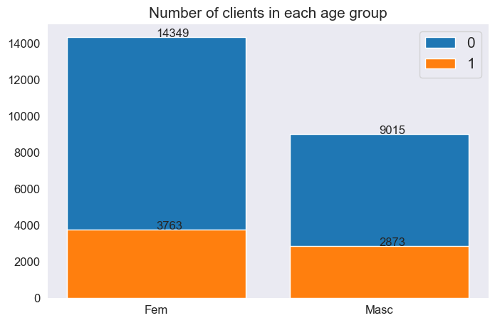

```python
sex_0 = (dados_df.SEXO[dados_df['def_pay'] == 0].value_counts())
sex_1 = (dados_df.SEXO[dados_df['def_pay'] == 1].value_counts())
names= ['Fem', 'Masc']
plt.subplots(figsize=(8,5))
plt.bar(sex_0.index, sex_0.values, label='0')
plt.bar(sex_1.index, sex_1.values, label='1')
for x,y in zip(names,sex_0):
    plt.text(x,y,y,fontsize=12)
for x,y in zip(names,sex_1):
    plt.text(x,y,y,fontsize=12)
plt.xticks(fontsize=12)
plt.yticks(fontsize=12)
plt.title("Number of clients in each age group", fontsize=15)
plt.legend(loc='upper right', fontsize=15)

plt.show()
```

```python
dados_df['def_pay'].groupby(dados_df['SEXO']).value_counts()
```

```
SEXO  def_pay
Fem   0          14349
      1           3763
Masc  0           9015
      1           2873
Name: def_pay, dtype: int64
```

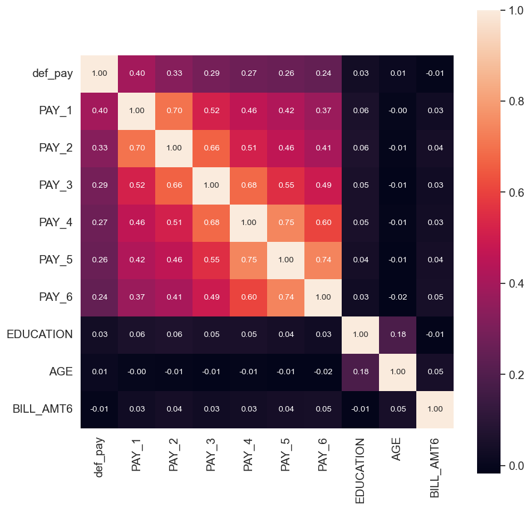

```python
#Matriz de correlação

k = 10 ## número de variáveis no mapa calor
corrmat = dados_df.corr()
cols = corrmat.nlargest(k, 'def_pay')['def_pay'].index ### variável dependente

cm = np.corrcoef(dados_df[cols].values.T)
sns.set(font_scale=1.25)
plt.subplots(figsize=(10,10))
hm = sns.heatmap(cm, cbar=True,
                 annot=True,
                 square=True,
                 fmt='.2f',

                 annot_kws={'size': 10},
                 yticklabels=cols.values,
                 xticklabels=cols.values)
plt.show()
```

É notável que existe uma correlação de inadimplência do próximo mês dependendo do status de pagamento dos últimos 6 meses. Ou seja, se o cliente atrasou no primeiro mês possivelmente tende mais chances de atrasar nos próximos. Se fizesse uma análise para ver o ponto de corte mais aprofundado que ocorre a estatbilização talvez seria nos últimos 2-3 meses para causar um default.

### Aplicação da Metodologia

Separando do dataset a variável alvo (dependente) das demais e dividir os dados entre dados de treino e teste com a funçõ trains_test_split.

```python
# separar as variáveis independentes da variável alvo (dependente)
X = dados_df.drop(['def_pay', 'ID'], axis=1).select_dtypes(exclude='object')
y = dados_df['def_pay']
```

### Separação entre treino e teste

```python
# dividir o dataset entre treino e teste
### 80% Treino
### 20% Teste

X_train, X_test, y_train, y_test = train_test_split(X,y,
                                                    test_size=0.2,
                                                    random_state=2,
                                                    stratify=y)
```

```python
### Percentual na base de dados (Treino e Teste)  variável resposta
print('Dados de teste: \n', y_test.value_counts(),'\n')

print('Dados de treino: \n', y_train.value_counts(),'\n')
## 22% default 1
## 78% default 0
```

```
Dados de teste:
 0    4673
1    1327
Name: def_pay, dtype: int64

Dados de treino:
 0    18691
1     5309
Name: def_pay, dtype: int64
```

### Aplicando Modelos de ML

Para avaliação dos algoritmos utilizados, será utilizado as seguintes métricas:

- GINI;
- KS;
- Área sob a curva ROC;
- Acurácia: indica uma perfromance geral do modelo. Ou seja, dentre todas as classificaçãoes, quantas no geral o modelo classificou corretamente

```python
### kfoldes (número de partições)

# armazenar os resultados
score = {}
kf = KFold(n_splits=5, random_state=0, shuffle=True)

xgb_model = XGBClassifier(learning_rate=0.01,   ## Taxa de aprendizado
                          max_depth=6,          ## Degraus das árvores
                          min_child_weight=3,
                     subsample=0.9,
                          colsample_bylevel=0.85,
                          n_estimators=900)
```

```python
xgb_model= xgb_model.fit(X_train, y_train)
```

```python
y_predito= xgb_model.predict(X_test)
```

### Métricas

```python
xgb = cross_validate(xgb_model,
                     X_train,
                     y_train,
                     cv=kf,
                     scoring=['accuracy', 'precision', 'recall', 'roc_auc'])
```

```python
summary = pd.DataFrame({
            'labels': ['accuracy', 'precision', 'recall', 'roc_auc'],

            'xgb': [xgb['test_accuracy'].mean(), xgb['test_precision'].mean(), xgb['test_recall'].mean(), xgb['test_roc_auc'].mean()]
}).set_index('labels')
summary.index.name=None
summary = summary.transpose()
summary.style.applymap(lambda x: 'background-color: lightgreen' if x >= 0.5 else '')
```

|  | accuracy | precision | recall | roc_auc |
| --- | --- | --- | --- | --- |
| xgb | 0.819125 | 0.669838 | 0.360751 | 0.780593 |

```python
roc_ac= cross_val_score(xgb_model, X_train, y_train, n_jobs=1, cv=kf, scoring='roc_auc').mean()
roc_ac
```

```
0.7805930012710611
```

```python
roc_ac_T= cross_val_score(xgb_model, X_test, y_test, n_jobs=1, cv=kf, scoring='roc_auc').mean()
roc_ac_T
```

```
0.7764913645982489
```

```python
# previsões e probabilidades em cima do dataset de treino
xgb_gini= 2 * roc_ac-1
xgb_ks= 2 * roc_ac-1/1.3

xgb_gini1= 2 * roc_ac_T-1
xgb_ks1= 2 * roc_ac_T-1/1.3


# ver performance do algoritmo
print("\nGINI SCORE TREINO:")
print (xgb_gini)

print("\nKS SCORE TREINO:")
print (xgb_ks)

print("\nGINI SCORE TESTE:")
print (xgb_gini1)

print("\nKS SCORE TESTE:")
print (xgb_ks1)
```

```
GINI SCORE TREINO:
0.5611860025421223

KS SCORE TREINO:
0.7919552333113531

GINI SCORE TESTE:
0.5529827291964977

KS SCORE TESTE:
0.7837519599657286
```

### Utilizando o SHAP:

para avaliar a importância das variáveis, para avaliar no conjunto de treinamento como cada valor de cada variável influenciou no resultado alcançado dado o modelo preditivo. Ou seja, qual a porcentagem X que o modelo apresentou para dizer se a classe correta é 0 (não inadimplente) ou 1 (inadimplente),

```python
# Cálculo do SHAP - Definindo explainer com características desejadas
explainer = shap.TreeExplainer(model=xgb_model)

# Cálculo do SHAP
shap_values_train = explainer.shap_values(X_train, y_train)
```

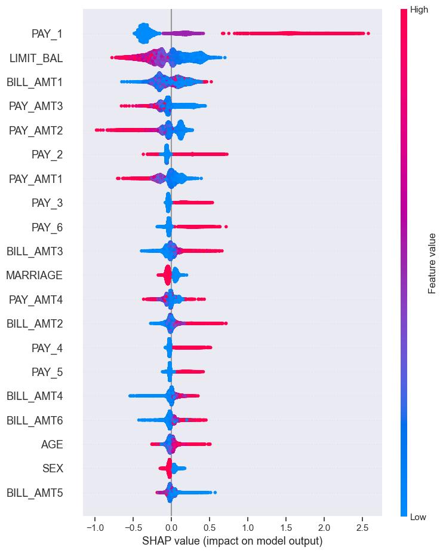

```python
# summarize the effects of all the features
shap.summary_plot(shap_values_train, X_train)
```

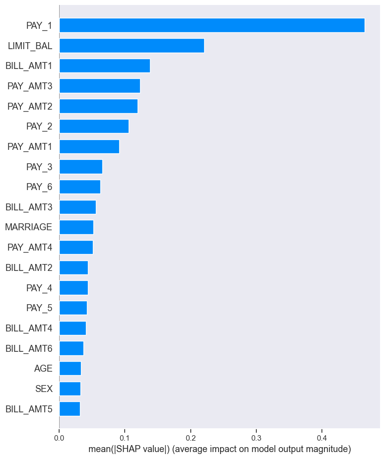

```python
shap.summary_plot(shap_values_train, X_train, plot_type="bar")
```

## Probabilidade de inadimplência:

```python
dados_df['probab'] = xgb_model.predict_proba(X[X_train.columns])[:,1]
dados_df[['ID','probab']]
```

|  | ID | probab |
| --- | --- | --- |
| 0 | 1 | 0.747495 |
| 1 | 2 | 0.469506 |
| 2 | 3 | 0.106665 |
| 3 | 4 | 0.163134 |
| 4 | 5 | 0.053794 |
| ... | ... | ... |
| 29995 | 29996 | 0.054148 |
| 29996 | 29997 | 0.110843 |
| 29997 | 29998 | 0.703735 |
| 29998 | 29999 | 0.315534 |
| 29999 | 30000 | 0.173764 |

30000 rows × 2 columns

Agora tem a probabilidade do cliente ser Inadimplente e pode-se criar ações com base nisso.

## Separando por decil:

```python
dados_df['QuantilRank'] = pd.qcut(dados_df['probab'], 10, labels=False)
```

```python
dados_df.head()
```

|  | ID | LIMIT_BAL | SEX | EDUCATION | MARRIAGE | AGE | PAY_1 | PAY_2 | PAY_3 | PAY_4 | PAY_5 | PAY_6 | BILL_AMT1 | BILL_AMT2 | BILL_AMT3 | BILL_AMT4 | BILL_AMT5 | BILL_AMT6 | PAY_AMT1 | PAY_AMT2 | PAY_AMT3 | PAY_AMT4 | PAY_AMT5 | PAY_AMT6 | def_pay | probab | QuantilRank |
| --- | --- | --- | --- | --- | --- | --- | --- | --- | --- | --- | --- | --- | --- | --- | --- | --- | --- | --- | --- | --- | --- | --- | --- | --- | --- | --- | --- |
| 0 | 1 | 20000.0 | 2 | 2 | 1 | 24 | 2 | 2 | 0 | 0 | 0 | 0 | 3913.0 | 3102.0 | 689.0 | 0.0 | 0.0 | 0.0 | 0.0 | 689.0 | 0.0 | 0.0 | 0.0 | 0.0 | 1 | 0.747495 | 9 |
| 1 | 2 | 120000.0 | 2 | 2 | 2 | 26 | 0 | 2 | 0 | 0 | 0 | 2 | 2682.0 | 1725.0 | 2682.0 | 3272.0 | 3455.0 | 3261.0 | 0.0 | 1000.0 | 1000.0 | 1000.0 | 0.0 | 2000.0 | 1 | 0.469506 | 8 |
| 2 | 3 | 90000.0 | 2 | 2 | 2 | 34 | 0 | 0 | 0 | 0 | 0 | 0 | 29239.0 | 14027.0 | 13559.0 | 14331.0 | 14948.0 | 15549.0 | 1518.0 | 1500.0 | 1000.0 | 1000.0 | 1000.0 | 5000.0 | 0 | 0.106665 | 3 |
| 3 | 4 | 50000.0 | 2 | 2 | 1 | 37 | 0 | 0 | 0 | 0 | 0 | 0 | 46990.0 | 48233.0 | 49291.0 | 28314.0 | 28959.0 | 29547.0 | 2000.0 | 2019.0 | 1200.0 | 1100.0 | 1069.0 | 1000.0 | 0 | 0.163134 | 5 |
| 4 | 5 | 50000.0 | 1 | 2 | 1 | 57 | 0 | 0 | 0 | 0 | 0 | 0 | 8617.0 | 5670.0 | 35835.0 | 20940.0 | 19146.0 | 19131.0 | 2000.0 | 36681.0 | 10000.0 | 9000.0 | 689.0 | 679.0 | 0 | 0.053794 | 0 |

```python
dados_df['QuantilRank'].describe()
```

```
count    30000.000000
mean         4.500000
std          2.872329
min          0.000000
25%          2.000000
50%          4.500000
75%          7.000000
max          9.000000
Name: QuantilRank, dtype: float64
```